# **Context:**

A new football club named ‘GL United FC’ has just been inaugurated. This club does not have a team yet. The team is looking to hire players for their roster. Management wants to make such decisions using a data based approach. During a recent hiring drive, you were selected for the Data Science team as a data scientist.

Your team has been tasked with creating a report which recommends players for the main team. To start with, a total of 15 players are required. Player data for all teams has been acquired from FIFA. This data contains information about the players, the clubs they are currently playing for and various performance measures. The team needs 20 possible players to choose from. You have been requested to do the analysis and formulate a report in order to help the management make a decision regarding potential players.

# Dataset Description:

The data contains details for over 18,000 players playing in various football clubs in Europe. It contains information on age, skill rating, wages and player value, etc. The files provided are as follows:

- fifa.csv – data file.
- fifa_ variable_information.csv - information on individual variables.

# Questions: (Total points: 50)

## ● Load and explore data (4 points)

### 1. Import the required libraries and read the dataset. (1 point)

```python
import pandas as pd
import numpy as np
import seaborn as sns
import matplotlib.pyplot as plt
import warnings
warnings.filterwarnings('ignore')
```

```python
fifa_Var_Info=pd.read_csv('fifa_ variable_information.csv')
fifa = pd.read_csv('fifa.csv')
```

### 2. Check the first few samples, shape, info of the data and try to familiarize yourself with different features. (2 points)

```python
fifa.head()
```

|  | ID | Name | Age | Photo | Nationality | Flag | Overall | Potential | Club | Club Logo | ... | Composure | Marking | StandingTackle | SlidingTackle | GKDiving | GKHandling | GKKicking | GKPositioning | GKReflexes | Release Clause |
| --- | --- | --- | --- | --- | --- | --- | --- | --- | --- | --- | --- | --- | --- | --- | --- | --- | --- | --- | --- | --- | --- |
| 0 | 158023 | L. Messi | 31 | https://cdn.sofifa.org/players/4/19/158023.png | Argentina | https://cdn.sofifa.org/flags/52.png | 94 | 94 | FC Barcelona | https://cdn.sofifa.org/teams/2/light/241.png | ... | 96.0 | 33.0 | 28.0 | 26.0 | 6.0 | 11.0 | 15.0 | 14.0 | 8.0 | €226.5M |
| 1 | 20801 | Cristiano Ronaldo | 33 | https://cdn.sofifa.org/players/4/19/20801.png | Portugal | https://cdn.sofifa.org/flags/38.png | 94 | 94 | Juventus | https://cdn.sofifa.org/teams/2/light/45.png | ... | 95.0 | 28.0 | 31.0 | 23.0 | 7.0 | 11.0 | 15.0 | 14.0 | 11.0 | €127.1M |
| 2 | 190871 | Neymar Jr | 26 | https://cdn.sofifa.org/players/4/19/190871.png | Brazil | https://cdn.sofifa.org/flags/54.png | 92 | 93 | Paris Saint-Germain | https://cdn.sofifa.org/teams/2/light/73.png | ... | 94.0 | 27.0 | 24.0 | 33.0 | 9.0 | 9.0 | 15.0 | 15.0 | 11.0 | €228.1M |
| 3 | 193080 | De Gea | 27 | https://cdn.sofifa.org/players/4/19/193080.png | Spain | https://cdn.sofifa.org/flags/45.png | 91 | 93 | Manchester United | https://cdn.sofifa.org/teams/2/light/11.png | ... | 68.0 | 15.0 | 21.0 | 13.0 | 90.0 | 85.0 | 87.0 | 88.0 | 94.0 | €138.6M |
| 4 | 192985 | K. De Bruyne | 27 | https://cdn.sofifa.org/players/4/19/192985.png | Belgium | https://cdn.sofifa.org/flags/7.png | 91 | 92 | Manchester City | https://cdn.sofifa.org/teams/2/light/10.png | ... | 88.0 | 68.0 | 58.0 | 51.0 | 15.0 | 13.0 | 5.0 | 10.0 | 13.0 | €196.4M |

5 rows × 60 columns

```python
fifa.shape
```

```
(18207, 60)
```

```python
fifa.info()
```

```
<class 'pandas.core.frame.DataFrame'>
RangeIndex: 18207 entries, 0 to 18206
Data columns (total 60 columns):
 #   Column                    Non-Null Count  Dtype
---  ------                    --------------  -----
 0   ID                        18207 non-null  int64
 1   Name                      18207 non-null  object
 2   Age                       18207 non-null  int64
 3   Photo                     18207 non-null  object
 4   Nationality               18207 non-null  object
 5   Flag                      18207 non-null  object
 6   Overall                   18207 non-null  int64
 7   Potential                 18207 non-null  int64
 8   Club                      17966 non-null  object
 9   Club Logo                 18207 non-null  object
```

[output cut: 52 more lines]

```python
#fifa_ variable_information discription
fifa_Var_Info.describe().T
```

|  | count | unique | top | freq |
| --- | --- | --- | --- | --- |
| ID | 59 | 59 | Name | 1 |
| unique id for every player | 59 | 25 | rating on scale of 100 | 33 |

### 3. Drop the columns which you think redundant for the analysis. (1 point)

[Hint: columns like 'Photo','Flag','Club Logo']

```python
# Checking the total no. of columns
print("Total columns : " , len(fifa.columns))
```

```
Total columns :  60
```

```python
# Droping the columns which are redundant for the analysis

fifa.drop(columns=['Photo', 'Flag', 'Club Logo', 'Loaned From'], inplace=True)

# Rechecking the total no. of columns
print("Tatal columns after dropping redundant columns : ", len(fifa.columns))
```

```
Tatal columns after dropping redundant columns :  56
```

```python
# Checking the table after dropping redundant columns
fifa.head()
```

|  | ID | Name | Age | Nationality | Overall | Potential | Club | Value | Wage | Preferred Foot | ... | Composure | Marking | StandingTackle | SlidingTackle | GKDiving | GKHandling | GKKicking | GKPositioning | GKReflexes | Release Clause |
| --- | --- | --- | --- | --- | --- | --- | --- | --- | --- | --- | --- | --- | --- | --- | --- | --- | --- | --- | --- | --- | --- |
| 0 | 158023 | L. Messi | 31 | Argentina | 94 | 94 | FC Barcelona | €110.5M | €565K | Left | ... | 96.0 | 33.0 | 28.0 | 26.0 | 6.0 | 11.0 | 15.0 | 14.0 | 8.0 | €226.5M |
| 1 | 20801 | Cristiano Ronaldo | 33 | Portugal | 94 | 94 | Juventus | €77M | €405K | Right | ... | 95.0 | 28.0 | 31.0 | 23.0 | 7.0 | 11.0 | 15.0 | 14.0 | 11.0 | €127.1M |
| 2 | 190871 | Neymar Jr | 26 | Brazil | 92 | 93 | Paris Saint-Germain | €118.5M | €290K | Right | ... | 94.0 | 27.0 | 24.0 | 33.0 | 9.0 | 9.0 | 15.0 | 15.0 | 11.0 | €228.1M |
| 3 | 193080 | De Gea | 27 | Spain | 91 | 93 | Manchester United | €72M | €260K | Right | ... | 68.0 | 15.0 | 21.0 | 13.0 | 90.0 | 85.0 | 87.0 | 88.0 | 94.0 | €138.6M |
| 4 | 192985 | K. De Bruyne | 27 | Belgium | 91 | 92 | Manchester City | €102M | €355K | Right | ... | 88.0 | 68.0 | 58.0 | 51.0 | 15.0 | 13.0 | 5.0 | 10.0 | 13.0 | €196.4M |

5 rows × 56 columns

```python
# Rechecking the columns details
fifa.shape
```

```
(18207, 56)
```

## ● Data Cleaning and Preprocessing (18 points)

### 4. Convert the columns "Value", "Wage", "Release Clause" to float datatype

after getting rid of currency symbol and suffix. (6 points)

- Note: When the record/entry has "M"(indicates millions) as suffix you need to multiply that value with 1000000
- When the record/entry has "K"(indicates thousands) as suffix you need to multiply that value with 1000

```python
# Getting rid of currency symbol and suffix.
fifa['Value'] = fifa['Value'].str.replace("€","")
fifa['Wage'] = fifa['Wage'].str.replace("€","")
fifa['Release Clause'] = fifa['Release Clause'].str.replace("€","")
```

```python
    def convert_currency1(x):
        if isinstance(x, str):
            return (x.replace('M', '').replace(',', ''))
        return (x)
```

```python
    def convert_currency2(x):
        if isinstance(x, str):
            return (x.replace('€', '').replace(',', ''))
        return (x)
```

```python
    def convert_currency3(x):
        if isinstance(x, str):
            return (x.replace('K', '').replace(',', ''))
        return (x)
```

```python
fifa['Value'] = fifa['Value'].apply(convert_currency1)
fifa['Value'] = fifa['Value'].apply(convert_currency2)
fifa['Value'] = fifa['Value'].apply(convert_currency3)
fifa['Value'] = fifa['Value'].astype('float')
```

```python
fifa['Wage'] = fifa['Wage'].apply(convert_currency1)
fifa['Wage'] = fifa['Wage'].apply(convert_currency2)
fifa['Wage'] = fifa['Wage'].apply(convert_currency3)
fifa['Wage'] = fifa['Wage'].astype('float')
```

```python
fifa['Release Clause'] = fifa['Release Clause'].apply(convert_currency1)
fifa['Release Clause'] = fifa['Release Clause'].apply(convert_currency2)
fifa['Release Clause'] = fifa['Release Clause'].apply(convert_currency3)
fifa['Release Clause'] = fifa['Release Clause'].astype('float')
```

```python
#Remove NaN values in columns such as 'Value' 'Wage' 'Release Clause'
fifa.fillna({'Value':0},inplace=True)
fifa.fillna({'Wage':0},inplace=True)
fifa.fillna({'Release Clause':0},inplace=True)
```

```python
# fifa['Release Clause'].astype(int)
fifa['Release Clause']
```

```
0        226.5
1        127.1
2        228.1
3        138.6
4        196.4
         ...
18202    143.0
18203    113.0
18204    165.0
18205    143.0
18206    165.0
Name: Release Clause, Length: 18207, dtype: float64
```

```python
#Calling function varb_clear() to remove 'M' ,'K' in replace digits
fifa['Value']=fifa['Value']*1000000
fifa['Wage']=fifa['Wage']*1000
fifa['Release Clause']=fifa['Release Clause']*1000000
```

```python
fifa.head()
```

|  | ID | Name | Age | Nationality | Overall | Potential | Club | Value | Wage | Preferred Foot | ... | Composure | Marking | StandingTackle | SlidingTackle | GKDiving | GKHandling | GKKicking | GKPositioning | GKReflexes | Release Clause |
| --- | --- | --- | --- | --- | --- | --- | --- | --- | --- | --- | --- | --- | --- | --- | --- | --- | --- | --- | --- | --- | --- |
| 0 | 158023 | L. Messi | 31 | Argentina | 94 | 94 | FC Barcelona | 110500000.0 | 565000.0 | Left | ... | 96.0 | 33.0 | 28.0 | 26.0 | 6.0 | 11.0 | 15.0 | 14.0 | 8.0 | 226500000.0 |
| 1 | 20801 | Cristiano Ronaldo | 33 | Portugal | 94 | 94 | Juventus | 77000000.0 | 405000.0 | Right | ... | 95.0 | 28.0 | 31.0 | 23.0 | 7.0 | 11.0 | 15.0 | 14.0 | 11.0 | 127100000.0 |
| 2 | 190871 | Neymar Jr | 26 | Brazil | 92 | 93 | Paris Saint-Germain | 118500000.0 | 290000.0 | Right | ... | 94.0 | 27.0 | 24.0 | 33.0 | 9.0 | 9.0 | 15.0 | 15.0 | 11.0 | 228100000.0 |
| 3 | 193080 | De Gea | 27 | Spain | 91 | 93 | Manchester United | 72000000.0 | 260000.0 | Right | ... | 68.0 | 15.0 | 21.0 | 13.0 | 90.0 | 85.0 | 87.0 | 88.0 | 94.0 | 138600000.0 |
| 4 | 192985 | K. De Bruyne | 27 | Belgium | 91 | 92 | Manchester City | 102000000.0 | 355000.0 | Right | ... | 88.0 | 68.0 | 58.0 | 51.0 | 15.0 | 13.0 | 5.0 | 10.0 | 13.0 | 196400000.0 |

5 rows × 56 columns

### 5. Convert the column "Joined" into integer data type with keeping only the year. (2 points)

```python
fifa.Joined = pd.to_datetime(fifa.Joined)
fifa['Joined'] = fifa.Joined.dt.year
fifa['Joined'] = fifa.Joined.fillna(0).astype(int)
```

```python
fifa.Joined
```

```
0        2004
1        2018
2        2017
3        2011
4        2015
         ...
18202    2017
18203    2018
18204    2017
18205    2018
18206    2018
Name: Joined, Length: 18207, dtype: int32
```

### 6. Convert the column "Contract Valid Until" to pandas datetime type. (2 points)

```python
fifa['Contract Valid Until']= pd.to_datetime(fifa['Contract Valid Until'])
```

```python
fifa['Contract Valid Until']
```

```
0       2021-01-01
1       2022-01-01
2       2022-01-01
3       2020-01-01
4       2023-01-01
           ...
18202   2019-01-01
18203   2020-01-01
18204   2021-01-01
18205   2019-01-01
18206   2019-01-01
Name: Contract Valid Until, Length: 18207, dtype: datetime64[ns]
```

### 7. The column 'Height' is in inches with a quotation mark, Convert to float with decimal points. (2 points)

```python
#in centimeter
def height_conversion(height):
    if((pd.isna(height))!= True):
        chk = str(height)
        h = []
        h = chk.split("'")
        ft = float(h[0])
        if( h[1] != ''):
            inch = float(h[1])
        else:
            inch = 0
        tot_inc = inch + ft*12
        h = tot_inc * 2.54
        return h
    else:
        return height

fifa['Height'] = fifa['Height'].apply(height_conversion)
```

```python
fifa['Height'] = fifa['Height'].fillna(value = fifa['Height'].mean())
fifa['Height'] = fifa['Height'].round(2)
fifa.Height
```

```
0        170.18
1        187.96
2        175.26
3        193.04
4        180.34
          ...
18202    175.26
18203    190.50
18204    172.72
18205    177.80
18206    177.80
Name: Height, Length: 18207, dtype: float64
```

### 8. The column "Weight" has the suffix as lbs, remove the suffix and convert to float. (2 points)

```python
#conversion in kg
def weight_conversion(weight):

    if((pd.isna(weight))!= True):
        w = int(weight[0:-3])*0.453592
        return w
    else:
        return weight

fifa['Weight'] = fifa['Weight'].apply(weight_conversion)
```

```python
fifa['Weight'] = fifa['Weight'].fillna(value = fifa['Weight'].mean())
```

```python
# Rounding the float value in 2 decimal no.
fifa['Weight'] = fifa['Weight'].round(2)
fifa.Weight
```

```
0        72.12
1        83.01
2        68.04
3        76.20
4        69.85
         ...
18202    60.78
18203    77.11
18204    67.13
18205    69.85
18206    79.83
Name: Weight, Length: 18207, dtype: float64
```

### 9. Check for the percentage of missing values and impute them with appropriate imputation techniques. (4 points)

```python
#sorting the missing values in rows in descending order
missing_values = (fifa.isnull().sum(axis=1))*100/len(fifa)
print(missing_values[missing_values > 0] )
```

```
452      0.010985
538      0.010985
568      0.010985
677      0.010985
874      0.010985
           ...
17197    0.010985
17215    0.010985
17339    0.021970
17436    0.021970
17539    0.021970
Length: 289, dtype: float64
```

```python
print("Before deleting rows",fifa.shape[0])
```

```
Before deleting rows 18207
```

```python
fifa = fifa[fifa.isnull().sum(axis=1)<=50]
print("AFter removing the rows having more than 50 missing values",fifa.shape[0])
```

```
AFter removing the rows having more than 50 missing values 18207
```

```python
t_null = fifa.isnull().sum()
percent_missing = t_null* 100 / fifa.shape[0]
tb={'Number of missing values':t_null,'Percentage of missing values':percent_missing}

df = pd.DataFrame(tb ,columns=['Number of missing values','Percentage of missing values'])
df.sort_values(by='Percentage of missing values',ascending=False)
```

|  | Number of missing values | Percentage of missing values |
| --- | --- | --- |
| Contract Valid Until | 289 | 1.587302 |
| Club | 241 | 1.323667 |
| Jersey Number | 60 | 0.329544 |
| Position | 60 | 0.329544 |
| FKAccuracy | 48 | 0.263635 |
| SprintSpeed | 48 | 0.263635 |
| Dribbling | 48 | 0.263635 |
| Curve | 48 | 0.263635 |
| Penalties | 48 | 0.263635 |
| LongPassing | 48 | 0.263635 |
| BallControl | 48 | 0.263635 |
| Acceleration | 48 | 0.263635 |
| Agility | 48 | 0.263635 |
| ShortPassing | 48 | 0.263635 |
| Reactions | 48 | 0.263635 |
| Balance | 48 | 0.263635 |
| ShotPower | 48 | 0.263635 |
| Jumping | 48 | 0.263635 |
| Stamina | 48 | 0.263635 |
| Strength | 48 | 0.263635 |
| LongShots | 48 | 0.263635 |
| Aggression | 48 | 0.263635 |
| Interceptions | 48 | 0.263635 |
| Volleys | 48 | 0.263635 |
| Finishing | 48 | 0.263635 |
| HeadingAccuracy | 48 | 0.263635 |
| International Reputation | 48 | 0.263635 |
| GKReflexes | 48 | 0.263635 |
| GKPositioning | 48 | 0.263635 |
| GKKicking | 48 | 0.263635 |
| GKHandling | 48 | 0.263635 |
| GKDiving | 48 | 0.263635 |
| SlidingTackle | 48 | 0.263635 |
| Preferred Foot | 48 | 0.263635 |
| Weak Foot | 48 | 0.263635 |
| Vision | 48 | 0.263635 |
| Skill Moves | 48 | 0.263635 |
| Work Rate | 48 | 0.263635 |
| Body Type | 48 | 0.263635 |
| StandingTackle | 48 | 0.263635 |
| Marking | 48 | 0.263635 |
| Composure | 48 | 0.263635 |
| Crossing | 48 | 0.263635 |
| Positioning | 48 | 0.263635 |
| ID | 0 | 0.000000 |
| Name | 0 | 0.000000 |
| Weight | 0 | 0.000000 |
| Height | 0 | 0.000000 |
| Joined | 0 | 0.000000 |
| Wage | 0 | 0.000000 |
| Value | 0 | 0.000000 |
| Potential | 0 | 0.000000 |
| Overall | 0 | 0.000000 |
| Nationality | 0 | 0.000000 |
| Age | 0 | 0.000000 |
| Release Clause | 0 | 0.000000 |

```python
fifa['Club']=fifa['Club'].fillna(fifa['Club'].mode()[0])
fifa['Position']=fifa['Position'].fillna(fifa['Position'].mode()[0])
fifa['Joined']=fifa['Joined'].fillna(fifa['Joined'].mode()[0])
fifa['Contract Valid Until']=fifa['Contract Valid Until'].fillna(fifa['Contract Valid Until'].mode()[0])
fifa['Release Clause']=fifa['Release Clause'].fillna(fifa['Release Clause'].mode()[0])
fifa['International Reputation']=fifa['International Reputation'].fillna(fifa['International Reputation'].mode()[0])
fifa.head()
```

|  | ID | Name | Age | Nationality | Overall | Potential | Club | Value | Wage | Preferred Foot | ... | Composure | Marking | StandingTackle | SlidingTackle | GKDiving | GKHandling | GKKicking | GKPositioning | GKReflexes | Release Clause |
| --- | --- | --- | --- | --- | --- | --- | --- | --- | --- | --- | --- | --- | --- | --- | --- | --- | --- | --- | --- | --- | --- |
| 0 | 158023 | L. Messi | 31 | Argentina | 94 | 94 | FC Barcelona | 110500000.0 | 565000.0 | Left | ... | 96.0 | 33.0 | 28.0 | 26.0 | 6.0 | 11.0 | 15.0 | 14.0 | 8.0 | 226500000.0 |
| 1 | 20801 | Cristiano Ronaldo | 33 | Portugal | 94 | 94 | Juventus | 77000000.0 | 405000.0 | Right | ... | 95.0 | 28.0 | 31.0 | 23.0 | 7.0 | 11.0 | 15.0 | 14.0 | 11.0 | 127100000.0 |
| 2 | 190871 | Neymar Jr | 26 | Brazil | 92 | 93 | Paris Saint-Germain | 118500000.0 | 290000.0 | Right | ... | 94.0 | 27.0 | 24.0 | 33.0 | 9.0 | 9.0 | 15.0 | 15.0 | 11.0 | 228100000.0 |
| 3 | 193080 | De Gea | 27 | Spain | 91 | 93 | Manchester United | 72000000.0 | 260000.0 | Right | ... | 68.0 | 15.0 | 21.0 | 13.0 | 90.0 | 85.0 | 87.0 | 88.0 | 94.0 | 138600000.0 |
| 4 | 192985 | K. De Bruyne | 27 | Belgium | 91 | 92 | Manchester City | 102000000.0 | 355000.0 | Right | ... | 88.0 | 68.0 | 58.0 | 51.0 | 15.0 | 13.0 | 5.0 | 10.0 | 13.0 | 196400000.0 |

5 rows × 56 columns

```python
fifa.isnull().sum().sum()
```

```
1932
```

## ● Exploratory Data Analysis (28 points)

### 10. Plot the distribution of Overall rating for all the players and write your findings. (2 points)

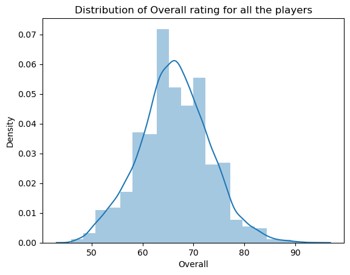

```python
sns.distplot(fifa['Overall'], bins = 20 )
plt.title('Distribution of Overall rating for all the players')
plt.show()
```

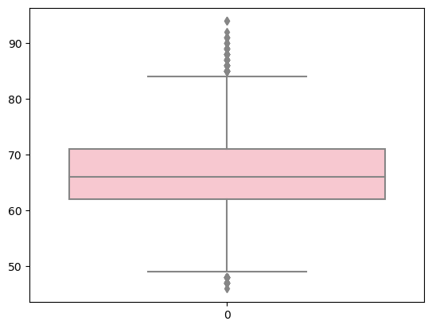

```python
sns.boxplot(fifa['Overall'], color='pink')
plt.show()
```

### 11. Retrieve the names of top20 players based on the Overall rating. (2 points)

```python
Top_20 = fifa.sort_values(by='Overall', ascending=False)
top_20 = Top_20.head(20)
print(top_20[['Name', 'Overall']])
```

```
                 Name  Overall
0            L. Messi       94
1   Cristiano Ronaldo       94
2           Neymar Jr       92
3              De Gea       91
4        K. De Bruyne       91
5           E. Hazard       91
6           L. Modrić       91
7           L. Suárez       91
8        Sergio Ramos       91
12           D. Godín       90
13        David Silva       90
9            J. Oblak       90
11           T. Kroos       90
10     R. Lewandowski       90
20    Sergio Busquets       89
24       G. Chiellini       89
23          S. Agüero       89
22           M. Neuer       89
21          E. Cavani       89
16            H. Kane       89
```

### 12. Generate a dataframe which should include all the information of the Top 20 players based on the Overall rating. (4 points)

```python
top_20 = pd.DataFrame(Top_20.head(20))
top_20
```

|  | ID | Name | Age | Nationality | Overall | Potential | Club | Value | Wage | Preferred Foot | ... | Composure | Marking | StandingTackle | SlidingTackle | GKDiving | GKHandling | GKKicking | GKPositioning | GKReflexes | Release Clause |
| --- | --- | --- | --- | --- | --- | --- | --- | --- | --- | --- | --- | --- | --- | --- | --- | --- | --- | --- | --- | --- | --- |
| 0 | 158023 | L. Messi | 31 | Argentina | 94 | 94 | FC Barcelona | 110500000.0 | 565000.0 | Left | ... | 96.0 | 33.0 | 28.0 | 26.0 | 6.0 | 11.0 | 15.0 | 14.0 | 8.0 | 226500000.0 |
| 1 | 20801 | Cristiano Ronaldo | 33 | Portugal | 94 | 94 | Juventus | 77000000.0 | 405000.0 | Right | ... | 95.0 | 28.0 | 31.0 | 23.0 | 7.0 | 11.0 | 15.0 | 14.0 | 11.0 | 127100000.0 |
| 2 | 190871 | Neymar Jr | 26 | Brazil | 92 | 93 | Paris Saint-Germain | 118500000.0 | 290000.0 | Right | ... | 94.0 | 27.0 | 24.0 | 33.0 | 9.0 | 9.0 | 15.0 | 15.0 | 11.0 | 228100000.0 |
| 3 | 193080 | De Gea | 27 | Spain | 91 | 93 | Manchester United | 72000000.0 | 260000.0 | Right | ... | 68.0 | 15.0 | 21.0 | 13.0 | 90.0 | 85.0 | 87.0 | 88.0 | 94.0 | 138600000.0 |
| 4 | 192985 | K. De Bruyne | 27 | Belgium | 91 | 92 | Manchester City | 102000000.0 | 355000.0 | Right | ... | 88.0 | 68.0 | 58.0 | 51.0 | 15.0 | 13.0 | 5.0 | 10.0 | 13.0 | 196400000.0 |
| 5 | 183277 | E. Hazard | 27 | Belgium | 91 | 91 | Chelsea | 93000000.0 | 340000.0 | Right | ... | 91.0 | 34.0 | 27.0 | 22.0 | 11.0 | 12.0 | 6.0 | 8.0 | 8.0 | 172100000.0 |
| 6 | 177003 | L. Modrić | 32 | Croatia | 91 | 91 | Real Madrid | 67000000.0 | 420000.0 | Right | ... | 84.0 | 60.0 | 76.0 | 73.0 | 13.0 | 9.0 | 7.0 | 14.0 | 9.0 | 137400000.0 |
| 7 | 176580 | L. Suárez | 31 | Uruguay | 91 | 91 | FC Barcelona | 80000000.0 | 455000.0 | Right | ... | 85.0 | 62.0 | 45.0 | 38.0 | 27.0 | 25.0 | 31.0 | 33.0 | 37.0 | 164000000.0 |
| 8 | 155862 | Sergio Ramos | 32 | Spain | 91 | 91 | Real Madrid | 51000000.0 | 380000.0 | Right | ... | 82.0 | 87.0 | 92.0 | 91.0 | 11.0 | 8.0 | 9.0 | 7.0 | 11.0 | 104600000.0 |
| 12 | 182493 | D. Godín | 32 | Uruguay | 90 | 90 | Atlético Madrid | 44000000.0 | 125000.0 | Right | ... | 82.0 | 90.0 | 89.0 | 89.0 | 6.0 | 8.0 | 15.0 | 5.0 | 15.0 | 90200000.0 |
| 13 | 168542 | David Silva | 32 | Spain | 90 | 90 | Manchester City | 60000000.0 | 285000.0 | Left | ... | 93.0 | 59.0 | 53.0 | 29.0 | 6.0 | 15.0 | 7.0 | 6.0 | 12.0 | 111000000.0 |
| 9 | 200389 | J. Oblak | 25 | Slovenia | 90 | 93 | Atlético Madrid | 68000000.0 | 94000.0 | Right | ... | 70.0 | 27.0 | 12.0 | 18.0 | 86.0 | 92.0 | 78.0 | 88.0 | 89.0 | 144500000.0 |
| 11 | 182521 | T. Kroos | 28 | Germany | 90 | 90 | Real Madrid | 76500000.0 | 355000.0 | Right | ... | 85.0 | 72.0 | 79.0 | 69.0 | 10.0 | 11.0 | 13.0 | 7.0 | 10.0 | 156800000.0 |
| 10 | 188545 | R. Lewandowski | 29 | Poland | 90 | 90 | FC Bayern München | 77000000.0 | 205000.0 | Right | ... | 86.0 | 34.0 | 42.0 | 19.0 | 15.0 | 6.0 | 12.0 | 8.0 | 10.0 | 127100000.0 |
| 20 | 189511 | Sergio Busquets | 29 | Spain | 89 | 89 | FC Barcelona | 51500000.0 | 315000.0 | Right | ... | 90.0 | 90.0 | 86.0 | 80.0 | 5.0 | 8.0 | 13.0 | 9.0 | 13.0 | 105600000.0 |
| 24 | 138956 | G. Chiellini | 33 | Italy | 89 | 89 | Juventus | 27000000.0 | 215000.0 | Left | ... | 84.0 | 93.0 | 93.0 | 90.0 | 3.0 | 3.0 | 2.0 | 4.0 | 3.0 | 44600000.0 |
| 23 | 153079 | S. Agüero | 30 | Argentina | 89 | 89 | Manchester City | 64500000.0 | 300000.0 | Right | ... | 90.0 | 30.0 | 20.0 | 12.0 | 13.0 | 15.0 | 6.0 | 11.0 | 14.0 | 119300000.0 |
| 22 | 167495 | M. Neuer | 32 | Germany | 89 | 89 | FC Bayern München | 38000000.0 | 130000.0 | Right | ... | 70.0 | 17.0 | 10.0 | 11.0 | 90.0 | 86.0 | 91.0 | 87.0 | 87.0 | 62700000.0 |
| 21 | 179813 | E. Cavani | 31 | Uruguay | 89 | 89 | Paris Saint-Germain | 60000000.0 | 200000.0 | Right | ... | 82.0 | 52.0 | 45.0 | 39.0 | 12.0 | 5.0 | 13.0 | 13.0 | 10.0 | 111000000.0 |
| 16 | 202126 | H. Kane | 24 | England | 89 | 91 | Tottenham Hotspur | 83500000.0 | 205000.0 | Right | ... | 89.0 | 56.0 | 36.0 | 38.0 | 8.0 | 10.0 | 11.0 | 14.0 | 11.0 | 160700000.0 |

20 rows × 56 columns

### 13. What is the average "Age" and "Wage" of these top 20 players? (use the data frame created in the question 11) (2 points)

```python
avg_age = Top_20['Age'].mean()
avg_wage = Top_20['Wage'].mean()
print("Average Age of Top 20 players: " , avg_age, "yrs")
print("Average Wage of Top 20 players: ", " €",avg_wage )
```

[output not shown]

### 14. Among the top 20 players based on the Overall rating, which player has the highest wage? Display the name of the player with his wage. (2 points)

```python
highest_player = top_20.sort_values(by = 'Wage', ascending= False).head(1)
print("Player with the highest wage --> ")
print(highest_player[['Name', 'Wage']])
```

```
Player with the highest wage -->
       Name      Wage
0  L. Messi  565000.0
```

### 15. Generate a dataframe which should include the "Player name", "Club Name", "Wage", and 'Overall rating'. (4 Points)

- i) find the average Overall rating for each club.
- ii) Display the average overall rating of Top10 Clubs using a plot

```python
df = fifa[['Name', 'Club', 'Wage', 'Overall']].copy()
df.head()
```

|  | Name | Club | Wage | Overall |
| --- | --- | --- | --- | --- |
| 0 | L. Messi | FC Barcelona | 565000.0 | 94 |
| 1 | Cristiano Ronaldo | Juventus | 405000.0 | 94 |
| 2 | Neymar Jr | Paris Saint-Germain | 290000.0 | 92 |
| 3 | De Gea | Manchester United | 260000.0 | 91 |
| 4 | K. De Bruyne | Manchester City | 355000.0 | 91 |

```python
avg_ratings = df.groupby('Club', as_index= False)['Overall'].mean()
avg_ratings.head(10)
```

|  | Club | Overall |
| --- | --- | --- |
| 0 | SSV Jahn Regensburg | 65.586207 |
| 1 | 1. FC Heidenheim 1846 | 65.750000 |
| 2 | 1. FC Kaiserslautern | 63.384615 |
| 3 | 1. FC Köln | 70.785714 |
| 4 | 1. FC Magdeburg | 65.615385 |
| 5 | 1. FC Nürnberg | 68.827586 |
| 6 | 1. FC Union Berlin | 68.321429 |
| 7 | 1. FSV Mainz 05 | 70.843750 |
| 8 | AC Ajaccio | 65.043478 |
| 9 | AC Horsens | 60.640000 |

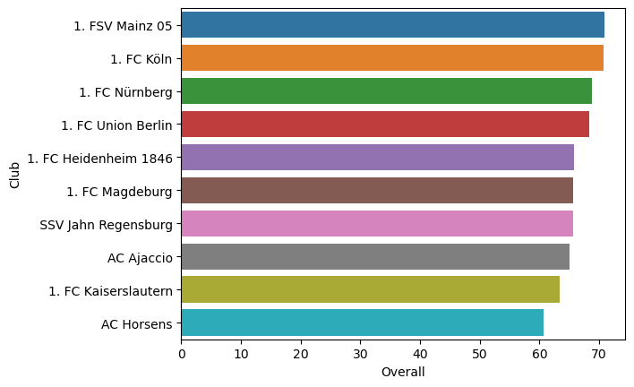

```python
#  Display the average overall rating of Top10 Clubs using a plot
top_10 = avg_ratings.head(10).sort_values(by='Overall', ascending=False)
sns.barplot(y= 'Club', x= 'Overall', data= top_10)
plt.show()
```

### 16. What is the relationship between age and individual potential of the player? Visualize the relationship with appropriate plot and Comment on the same. (2 points)

```python
corr_Ap = fifa[[ 'Age', 'Potential']].corr()
corr_Ap
```

|  | Age | Potential |
| --- | --- | --- |
| Age | 1.000000 | -0.253312 |
| Potential | -0.253312 | 1.000000 |

```python
fifa['Age'].corr(fifa['Potential'])
```

```
-0.2533121074109557
```

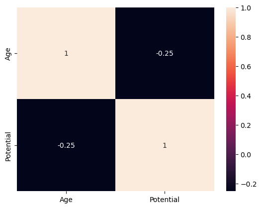

```python
sns.heatmap( corr_Ap, annot= True )
plt.show()
```

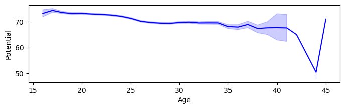

```python
# Visualize the relationship with appropriate plot and Comment on the same
plt.figure(figsize=(8,2))
sns.lineplot(x= 'Age', y= 'Potential', data = fifa, color='blue')
plt.show()
```

### 17. Which features directly contribute to the wages of the players? Support your answer with a plot and a metric. (2 points) (hint: use potential, Overall, value, international reputation, and Release Clause)

```python
wage_rel=fifa[['Potential','Overall','Value','International Reputation','Release Clause','Wage']]
wage_rel.corr()
```

|  | Potential | Overall | Value | International Reputation | Release Clause | Wage |
| --- | --- | --- | --- | --- | --- | --- |
| Potential | 1.000000 | 0.660939 | -0.231048 | 0.372887 | -0.379823 | 0.486413 |
| Overall | 0.660939 | 1.000000 | -0.233330 | 0.499654 | -0.379110 | 0.571926 |
| Value | -0.231048 | -0.233330 | 1.000000 | -0.207750 | 0.268746 | -0.247034 |
| International Reputation | 0.372887 | 0.499654 | -0.207750 | 1.000000 | -0.154821 | 0.668719 |
| Release Clause | -0.379823 | -0.379110 | 0.268746 | -0.154821 | 1.000000 | -0.206646 |
| Wage | 0.486413 | 0.571926 | -0.247034 | 0.668719 | -0.206646 | 1.000000 |

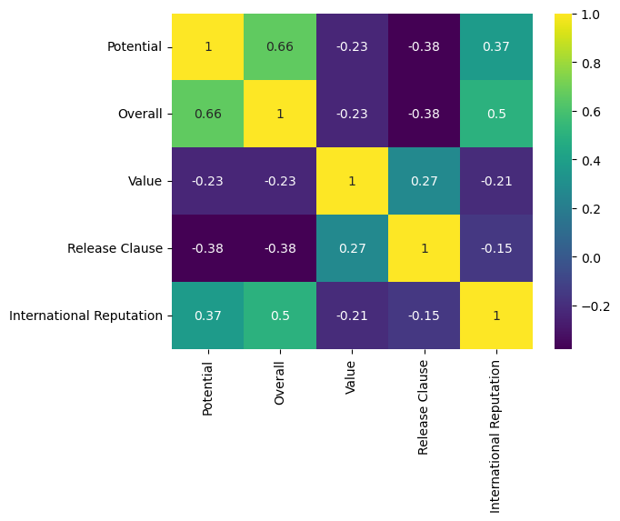

```python
sns.heatmap(wage_rel[['Potential','Overall','Value','Release Clause','International Reputation']].corr(),annot=True,cmap='viridis')
```

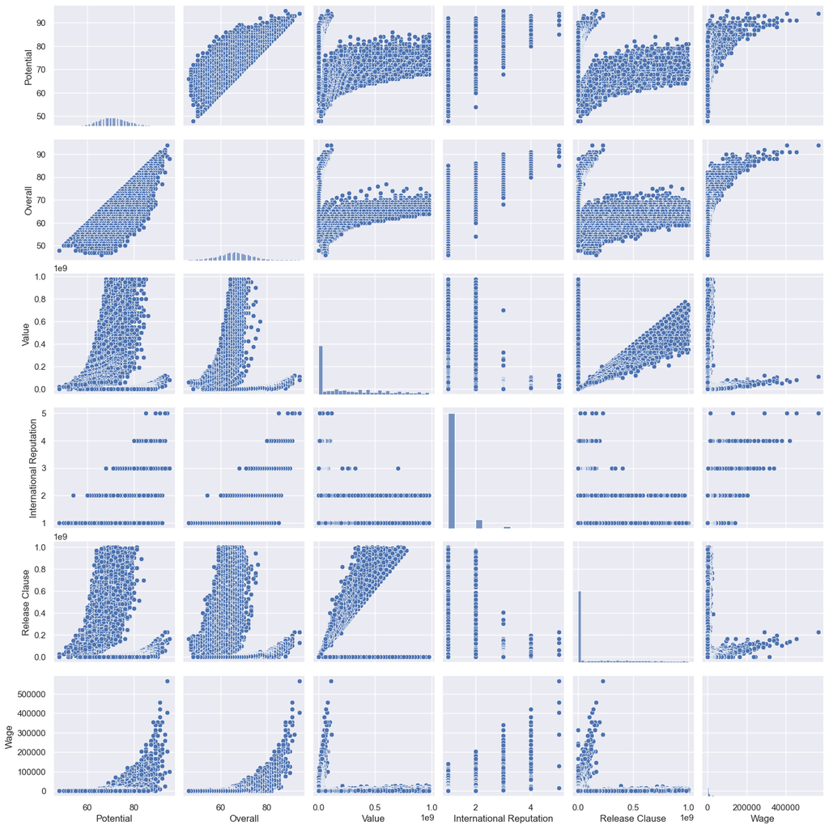

```python
sns.set()
cols = ['Potential','Overall', 'Value', 'International Reputation', 'Release Clause', 'Wage']
sns.pairplot(wage_rel[cols], height = 2.5)
plt.show()
```

### 18. Find the position in the pitch where the maximum number of players play and the position where the minimum number of players play? Display it using a plot. (2 points)

```python
Df_pos=fifa.groupby(['Position'])['Position'].count().reset_index(name='Count').sort_values(by=('Count'),ascending=False)

print("Maximum players at Position :"+ Df_pos['Position'][Df_pos['Count']==Df_pos['Count'].max()].iloc[0])
print("Minimum players  at Position :"+ Df_pos['Position'][Df_pos['Count']==Df_pos['Count'].min()].iloc[0])
```

```
Maximum players at Position :ST
Minimum players  at Position :LF
```

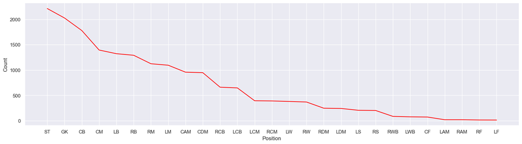

```python
# Display it using a plot.
plt.figure(figsize=(20,5))
sns.lineplot(x= 'Position', y= 'Count', data = Df_pos, color='red')
plt.show()
```

### 19. How many players are from the club 'Juventus' and the wage is greater than 200K? Display all the information of such players. (2 points)

```python
Fifa_Juve = np.where((fifa['Club']=='Juventus') & (fifa['Wage']>200000))

Fifa_juve_filter = fifa.loc[Fifa_Juve]

print(str(Fifa_juve_filter['Club'].count()) + " Players in Juventus Club with wages greater than 200k")
```

```
3 Players in Juventus Club with wages greater than 200k
```

```python
Fifa_juve_filter.head()
```

|  | ID | Name | Age | Nationality | Overall | Potential | Club | Value | Wage | Preferred Foot | ... | Composure | Marking | StandingTackle | SlidingTackle | GKDiving | GKHandling | GKKicking | GKPositioning | GKReflexes | Release Clause |
| --- | --- | --- | --- | --- | --- | --- | --- | --- | --- | --- | --- | --- | --- | --- | --- | --- | --- | --- | --- | --- | --- |
| 1 | 20801 | Cristiano Ronaldo | 33 | Portugal | 94 | 94 | Juventus | 77000000.0 | 405000.0 | Right | ... | 95.0 | 28.0 | 31.0 | 23.0 | 7.0 | 11.0 | 15.0 | 14.0 | 11.0 | 127100000.0 |
| 15 | 211110 | P. Dybala | 24 | Argentina | 89 | 94 | Juventus | 89000000.0 | 205000.0 | Left | ... | 84.0 | 23.0 | 20.0 | 20.0 | 5.0 | 4.0 | 4.0 | 5.0 | 8.0 | 153500000.0 |
| 24 | 138956 | G. Chiellini | 33 | Italy | 89 | 89 | Juventus | 27000000.0 | 215000.0 | Left | ... | 84.0 | 93.0 | 93.0 | 90.0 | 3.0 | 3.0 | 2.0 | 4.0 | 3.0 | 44600000.0 |

3 rows × 56 columns

### 20. Generate a data frame containing top 5 players by Overall rating for each unique position. (2 Points)

```python
df_top5_unique_pos = fifa.groupby(by = ['Position']).apply(lambda x: x.sort_values('Overall', ascending = False).head(5))
display(df_top5_unique_pos)
```

| Position |  | ID | Name | Age | Nationality | Overall | Potential | Club | Value | Wage | Preferred Foot | ... | Composure | Marking | StandingTackle | SlidingTackle | GKDiving | GKHandling | GKKicking | GKPositioning | GKReflexes | Release Clause |
| --- | --- | --- | --- | --- | --- | --- | --- | --- | --- | --- | --- | --- | --- | --- | --- | --- | --- | --- | --- | --- | --- | --- |
| CAM | 17 | 194765 | A. Griezmann | 27 | France | 89 | 90 | Atlético Madrid | 78000000.0 | 145000.0 | Left | ... | 87.0 | 59.0 | 47.0 | 48.0 | 14.0 | 8.0 | 14.0 | 13.0 | 14.0 | 165800000.0 |
|  | 31 | 190460 | C. Eriksen | 26 | Denmark | 88 | 91 | Tottenham Hotspur | 73500000.0 | 205000.0 | Right | ... | 88.0 | 59.0 | 57.0 | 22.0 | 9.0 | 14.0 | 7.0 | 7.0 | 6.0 | 141500000.0 |
|  | 61 | 201942 | Roberto Firmino | 26 | Brazil | 86 | 87 | Liverpool | 53000000.0 | 195000.0 | Right | ... | 87.0 | 60.0 | 64.0 | 42.0 | 8.0 | 11.0 | 9.0 | 6.0 | 10.0 | 104700000.0 |
|  | 66 | 189596 | T. Müller | 28 | Germany | 86 | 86 | FC Bayern München | 45000000.0 | 135000.0 | Right | ... | 83.0 | 44.0 | 41.0 | 44.0 | 6.0 | 7.0 | 11.0 | 14.0 | 14.0 | 74300000.0 |
|  | 74 | 176635 | M. Özil | 29 | Germany | 86 | 86 | Arsenal | 43500000.0 | 190000.0 | Left | ... | 82.0 | 24.0 | 16.0 | 19.0 | 6.0 | 14.0 | 10.0 | 6.0 | 14.0 | 82700000.0 |
| ... | ... | ... | ... | ... | ... | ... | ... | ... | ... | ... | ... | ... | ... | ... | ... | ... | ... | ... | ... | ... | ... | ... |
| ST | 1 | 20801 | Cristiano Ronaldo | 33 | Portugal | 94 | 94 | Juventus | 77000000.0 | 405000.0 | Right | ... | 95.0 | 28.0 | 31.0 | 23.0 | 7.0 | 11.0 | 15.0 | 14.0 | 11.0 | 127100000.0 |
|  | 10 | 188545 | R. Lewandowski | 29 | Poland | 90 | 90 | FC Bayern München | 77000000.0 | 205000.0 | Right | ... | 86.0 | 34.0 | 42.0 | 19.0 | 15.0 | 6.0 | 12.0 | 8.0 | 10.0 | 127100000.0 |
|  | 16 | 202126 | H. Kane | 24 | England | 89 | 91 | Tottenham Hotspur | 83500000.0 | 205000.0 | Right | ... | 89.0 | 56.0 | 36.0 | 38.0 | 8.0 | 10.0 | 11.0 | 14.0 | 11.0 | 160700000.0 |
|  | 23 | 153079 | S. Agüero | 30 | Argentina | 89 | 89 | Manchester City | 64500000.0 | 300000.0 | Right | ... | 90.0 | 30.0 | 20.0 | 12.0 | 13.0 | 15.0 | 6.0 | 11.0 | 14.0 | 119300000.0 |
|  | 36 | 173731 | G. Bale | 28 | Wales | 88 | 88 | Real Madrid | 60000000.0 | 355000.0 | Left | ... | 86.0 | 54.0 | 55.0 | 52.0 | 15.0 | 15.0 | 11.0 | 5.0 | 6.0 | 123000000.0 |

135 rows × 56 columns

### 21. What is the average wage one can expect to pay for the top 5 players in every position? (use the data frame created in Q19) (2 points)

```python
avg_wage= df_top5_unique_pos['Wage'].groupby('Position').apply(np.mean)
print(avg_wage)
```

```
Position
CAM    174000.0
CB     139600.0
CDM    217000.0
CF      47400.0
CM     130600.0
GK     192800.0
LAM     81600.0
LB     177200.0
LCB    162000.0
LCM    184400.0
LDM    126600.0
LF     121200.0
LM     164600.0
LS     130200.0
LW     261000.0
LWB     34200.0
RAM     45400.0
RB     155400.0
RCB    231000.0
RCM    240800.0
RDM    105000.0
RF     148000.0
RM     131400.0
RS     132200.0
RW     202000.0
RWB     44200.0
ST     294000.0
Name: Wage, dtype: float64
```

##### Submission:

- Please submit the solution file in .html and .ipynb format on Olympus
- Add necessary comments wherever required